# exploration_template_slide_deck slides

## Project - Ford Go Bike 2017 Data Exploration

### By Somya Bharti

**This data set includes information about individual rides made in a bike-sharing system covering the greater San Francisco Bay area. I will be performing analysing and visualization for answering relevant questions.**

### Main features of my interest in the Dataset :

> - I'm most interested in figuring out what features are best for predicting the more number of bike trips in the dataset.

### Features in the dataset which will help me support our investigation :

> - According to the dataset, the features like Start Date, Time, Month, Duration of Trip and User Type will have the strongest effect on Bike Trips.

When are most trips taken in terms of time of day, day of the week, or month of the year? How long does the average trip take? Does the above depend on if a user is a subscriber or customer?

## Univariate Exploration

I will start by looking at distribution of the main variables.

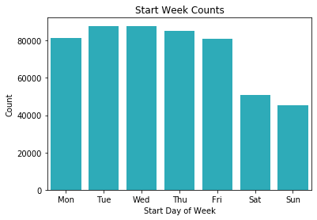

```python
week_days = ['Mon', 'Tue', 'Wed', 'Thu', 'Fri', 'Sat', 'Sun']
week_category = pd.api.types.CategoricalDtype(ordered=True, categories=week_days)
df_new['start_week'] = df_new['start_week'].astype(week_category)
base_color = sb.color_palette()[9]
sb.countplot(data=df_new, x='start_week', color=base_color);
plt.xlabel('Start Day of Week');
plt.ylabel('Count');
plt.title('Start Week Counts');
```

- We can see that less number of trips are taken on Weekends with respect to Weekdays.

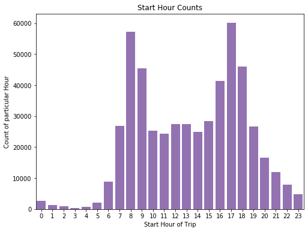

```python
fig_dims = (8,6)
fig, ax = plt.subplots(figsize=fig_dims)
base_color = sb.color_palette()[4]

sb.countplot(data=df_new, x='start_hour',ax=ax, color=base_color);
plt.xlabel('Start Hour of Trip');
plt.ylabel('Count of particular Hour');
plt.title('Start Hour Counts');
```

- We observe that most number of trips are taken around 8-9 am and around 4-6 pm in the evening.

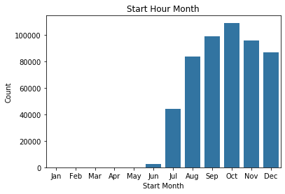

```python
months = ['Jan', 'Feb', 'Mar', 'Apr', 'May', 'Jun', 'Jul', 'Aug', 'Sep', 'Oct', 'Nov', 'Dec']
month_category = pd.api.types.CategoricalDtype(ordered=True, categories=months)
df_new['start_month'] = df_new['start_month'].astype(month_category)
base_color = sb.color_palette()[0]
sb.countplot(data=df_new, x='start_month', color=base_color);
plt.xlabel('Start Month');
plt.ylabel('Count');
plt.title('Start Hour Month');
```

During September, October and November, most of the trips are taken.

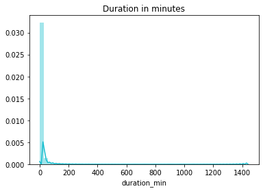

```python
base_color = sb.color_palette()[9]
sb.distplot(df_new['duration_min'],color=base_color);
plt.title('Duration in minutes');
```

- We will have to change the scale, as the plot is not evenly distributed for visualization.

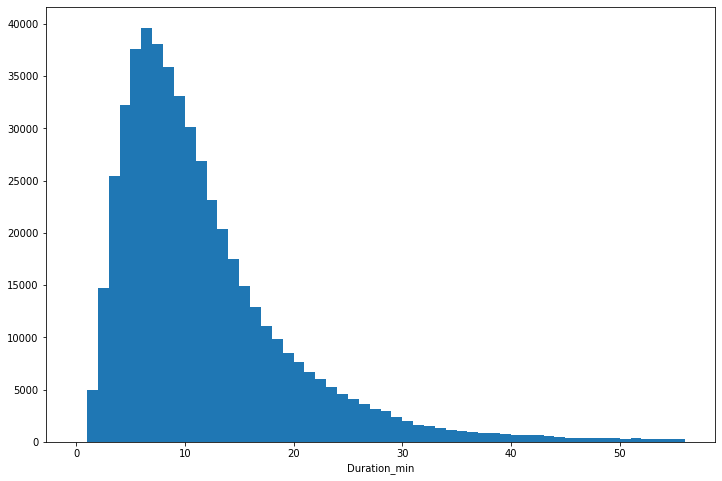

```python
binsize = 1
bins = np.arange(0, 57, binsize)

plt.figure(figsize=[12, 8])
plt.hist(data = df_new, x = 'duration_min', bins = bins)
plt.xlabel('Duration_min')
plt.show()
```

- We observe that most of trips have a duration of around 10 minutes.

### Distribution(s) of your variable(s) of interest.

> - While analyzing the duration time, we had to change the scale to fit our distribution. The other distributions fit well with the plots.

### Unusual distributions of the features and operations performed on the data to tidy, adjust, or change the form of the data.

> - I cleaned the features of the dataset for better visualization. For, extracting week, hour, time from the given Start_time, I changed its datatype. For, better visualization, I changed the duration in seconds to duration in minutes. I also dropped some of the columns which were not in use.

## Bivariate Exploration

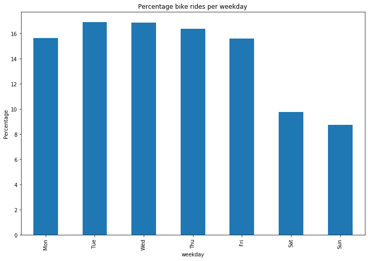

```python
weekday_trips = df_new.groupby('start_week').agg({'bike_id':'count'})
weekday_trips['perc'] = (weekday_trips['bike_id']/weekday_trips['bike_id'].sum())*100
weekday_index = ['Mon', 'Tue', 'Wed', 'Thu', 'Fri', 'Sat', 'Sun']
weekday_trips.reindex(weekday_index)['perc'].plot(kind='bar', figsize=(12,8))
plt.title('Percentage bike rides per weekday')
plt.xlabel('weekday')
plt.ylabel('Percentage');
```

- Percentage of bike rides are more during weekdays and less on weekends.

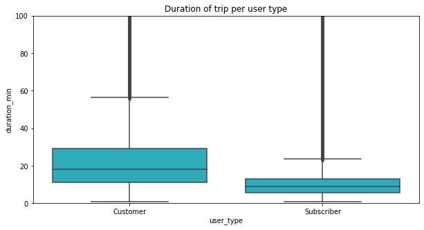

```python
plt.figure(figsize = [10, 5])
base_color = sb.color_palette()[9]

# left plot: violin plot
#plt.subplot(1, 2, 1)
ax1 = sb.boxplot(data = df_new, x = 'user_type', y = 'duration_min', color = base_color)
plt.ylim(0,100)
plt.title('Duration of trip per user type');

# right plot: box plot
```

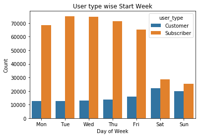

```python
sb.countplot(data=df_new, x='start_week', hue='user_type');
plt.xlabel('Day of Week');
plt.ylabel('Count');
plt.title('User type wise Start Week');
```

- It is found that customers usually go on trips during weekends with respect to weekdays.

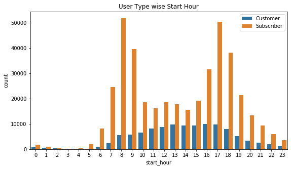

```python
plt.figure(figsize = [20, 5])

# left plot: clustered bar chart, absolute counts
plt.subplot(1, 2, 1)
sb.countplot(data = df_new, x = 'start_hour', hue = 'user_type')
plt.legend();
plt.title('User Type wise Start Hour');
```

- Subscribers take trips mostly during 8-9 am and 4-6 pm which is usually working hours of a company.

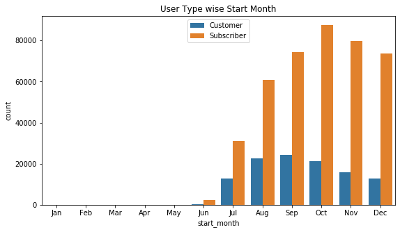

```python
plt.figure(figsize = [20, 5])

# left plot: clustered bar chart, absolute counts
plt.subplot(1, 2, 1)
sb.countplot(data = df_new, x = 'start_month', hue = 'user_type')
plt.legend();
plt.title('User Type wise Start Month');
```

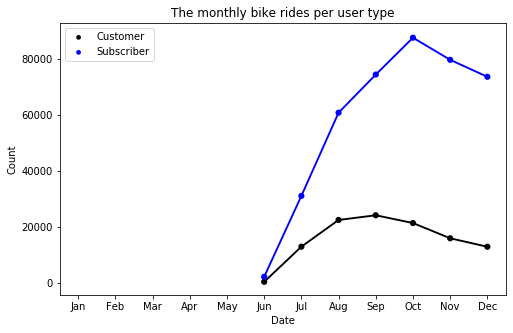

```python
user_type_count = df_new.groupby(["start_month", "user_type"]).size().reset_index()
plt.figure(figsize=(8,5))
color = {'Subscriber':'blue', 'Customer':'black'}
axis = sb.pointplot(x='start_month', y=0, hue='user_type', palette=color, scale=.7, data=user_type_count)
plt.title('The monthly bike rides per user type')
plt.xlabel('Date')
plt.ylabel('Count')
plt.legend();
```

- Subscribers take more trips as they are working people.

### Relationships between the other features (not the main feature(s) of interest).

October had the most bike riding usage for subscribers throughout the year.

## Multivariate Exploration

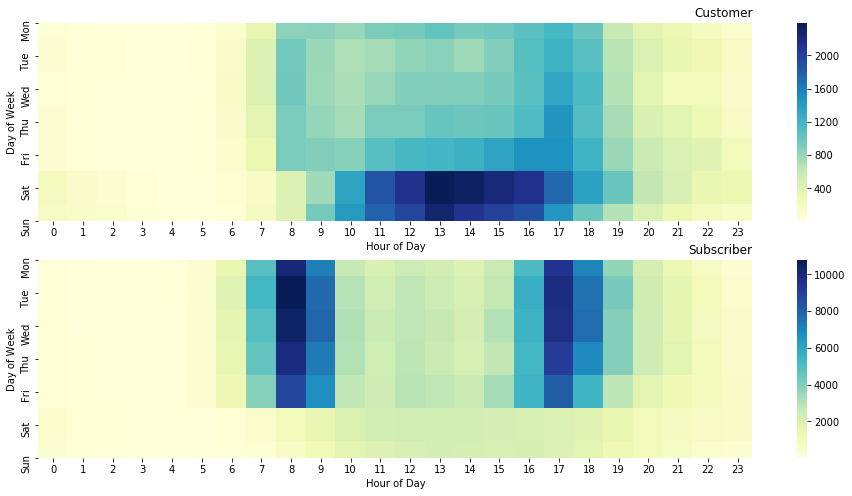

```python
plt.suptitle('Hourly Usage during Weekdays for Customers and Subscribers')
#fig, ax = plt.subplots(figsize=(5,5))

plt.figure(figsize = (16,8))
plt.subplot(2, 1, 1)
customers = df_new.query('user_type == "Customer"')
ct_counts = customers.groupby(['start_week', 'start_hour']).size()
ct_counts = ct_counts.reset_index(name='count')
ct_counts = ct_counts.pivot(index='start_week', columns='start_hour', values='count')
sb.heatmap(ct_counts, cmap='YlGnBu');
plt.title('Customer', loc='right');
plt.xlabel('Hour of Day');
plt.ylabel('Day of Week');

plt.subplot(2, 1, 2)
subscribers = df_new.query('user_type == "Subscriber"')
st_counts = subscribers.groupby(['start_week', 'start_hour']).size()
st_counts = st_counts.reset_index(name='count')
st_counts = st_counts.pivot(index='start_week', columns='start_hour', values='count')
sb.heatmap(st_counts, cmap='YlGnBu');
plt.title('Subscriber', loc='right');
plt.xlabel('Hour of Day');
plt.ylabel('Day of Week');
```

- By the above heat map, we can see clearly the trips taken by customers and subscribers on weekdays and weekends.

### Relationships you observed in this part of the investigation, Feature(s) of interest vary with other features in the dataset.

The relationship between the multiple variables plotted are visualized altogether and information are presented. The short period of usage for subscribers corresponds to their high concentration on rush hours Monday through Friday,which is for for work. The customer use shows that they're taking advantage of the bike sharing system quite differently from the subscribers, heavily over weekends and in the afternoon, for city tour or leisure purpose mostly.

### Relationships between the other features (not the main feature(s) of interest).

The interactions between features are all supplementing each other and quite make sense when looked at combined, there's no big surprise observed.